# Boat Manufacturer Profit Simulation using Breakpoint Method and Profit Optimization using Optimise Function

## Introduction

GWS is a company that markets outboard motorboats directly to consumers for recreational use. Recently, they’ve been developing a project they think has a lot of potential: the first mass market boats with electric motors. They haven’t started advertising their new product yet, nor have they organized a presale because they don’t want to lose their first-mover advantage. As a result, GWS has a limited understanding of the size of the market for their new project. They plan to retail their boats for $150,000, but after two years, when competition enters the market and the novelty factor wears off, they’ll have to drop the price to $70,000. They hire a consultant who estimates that at this price point, over the next two years, demand for the new boats will be somewhere between 2,000 and 15,000, with probabilities as in the table below:

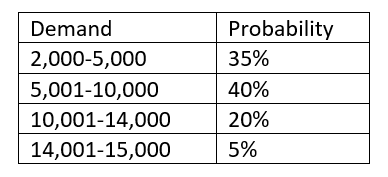

Demand Distribution

The fixed cost of manufacturing any number of boats is normally distributed, with a mean of $300 million and a standard deviation of $60 million. They estimate that the variable cost to produce one boat will be a minimum of $77 thousand and a maximum of $100 thousand, with a most likely value of $90,000.

This work covers:

**1. The simulation of expected total profit over the two year period assuming they produce:**

- 4,000 boats
- 8,000 boats
- 12,000 boats
- 15,000 boats

including the visualization of:

- line/ribbon plot depicting the mean profit as well as an 80% and a 95% confidence interval for GWS’ profit if they create between 2000 and 15000 boats, counting by increments of 1000.
- overlapping density plots depicting the distribution of GWS’ profit, assuming they create 2000, 4000, 6000, 8000, 10000, 12000, or 14,000 boats.

Analysis utilized Monte Carlo Simulation to incorporate uncertainty factor for the expected profit for GWS company.

**2. Optimization analysis to determine the number of boats GWS should produce to maximize:**

- GWS expected profit
- The 10th percentile of GWS profit
- The probability that GWS will earn a profit of at least $50 million

## Analysis

### Importing relevant libraries

```r
library(tidyverse)
library(stats)
library(triangle)
library(fitdistrplus)
library(purrr)
library(scales)
library(reshape2)
library(formattable)
library(matrixcalc)
library(Matrix)
library(MultiRNG)
library(DEoptim)
```

### Calculating Profit

Profit is calculated by using formula Profit = Revenue - Total Cost

In the context of GWS profit, calculation for the total expected profit for GWS with several production scenarios (4000, 8000, 12000, and 15000 boats) could be modeled by modeling the variables that affect the profit as follows:

#### 1. Revenue

As suggested by the assignment question, GWS is expecting the demand to be somewhere between 2,000 and 15,000, with probabilities as shown in the introduction part. The demand could be modeled using the Breakpoints Method and then the Revenue could be broken down into two parts:

1. Revenue_sales = (Demand Distribution * Selling Price) if the simulated demand is more than or equal to production.
2. Revenue_left = (Inventory Left-over * Adjusted Selling Price) if the simulated demand is less than production. Inventory Left-over is the number of boats that is not being sold in that particular simulation iteration.

Below code will be used to estimate the Revenue for each of the production scenario. Note that for each of the production scenario, 10,000 Monte Carlo simulation will be conducted:

```r
# Setting seed for reproducibility
set.seed(616)

# Creating vector of expected probabilities and associated demands
probs <- c(0.35, 0.75, 0.95, 1)
ints <- c(2000, 5001, 10001, 14001, 15000)

# Creating vector of production scenarios question 1a
boat_production <- seq(from = 2000, to = 15000, by = 1000)
# Creating vector of production scenarios question 1b
boat_production_2 <- c(2000, 4000, 6000, 8000, 10000, 12000, 14000)

#Assigning variables to sale price of a boat
sale_price <- 150000
sale_price_left <- 70000

# Assigning number of Monte Carlo Iterations
n <- 10000

# Assigning uniformly generated random number to a variable for a probability of demand occurring
p <- runif(n)

# Estimating demand by creating breakpoints distribution using dplyr case_when
demand <- case_when(p<probs[1]~runif(n,ints[1],ints[2]),
               p<probs[2]~runif(n,ints[2],ints[3]),
               p<probs[3]~runif(n,ints[3],ints[4]),
               p<probs[4]~runif(n,ints[4],ints[5]))

# Creating function to calculate expected revenue
expected_revenue <- function(number_production){
  rv_demand <- demand
  m_rev <- rv_demand - number_production
  revenue <- ifelse(m_rev>0, number_production*sale_price, rv_demand*sale_price)
  return(revenue)
}

# Calculating revenue for all four production scenarios question 1a
revenue_all <- lapply(boat_production, expected_revenue)
# Calculating revenue for all four production scenarios question 1b
revenue_all_2 <- lapply(boat_production_2, expected_revenue)

# Calculating revenue for the rest of the boat that was not being sold in first 2 years
boat_left_revenue <- function(number_production){
  rv_demand <- demand
  m_rev_left <- rv_demand - number_production
  left_revenue <- ifelse(m_rev_left>0, 0, rv_demand*sale_price_left)
  return(left_revenue)
}

# Calculating left revenue for all four production scenarios question 1a
revenue_all_left <- lapply(boat_production, boat_left_revenue)
# Calculating left revenue for all four production scenarios question 1b
revenue_all_left_2 <- lapply(boat_production_2, boat_left_revenue)

# Calculating total revenue question 1a
total_revenue <- map2(revenue_all, revenue_all_left, ~ .x + .y)
# Calculating total revenue question 1b
total_revenue_2 <- map2(revenue_all_2, revenue_all_left_2, ~ .x + .y)
```

#### 2. Fixed Cost

As explained in the assignment prompt, The fixed cost of manufacturing any number of boats is normally distributed, with a mean of 300 million dollar and a standard deviation of 60 million dollar. Therefore, Fixed Cost could be modeled by using Normal Distribution.

Below code will be used to model the fixed cost to manufacture the boat as a normal distribution.

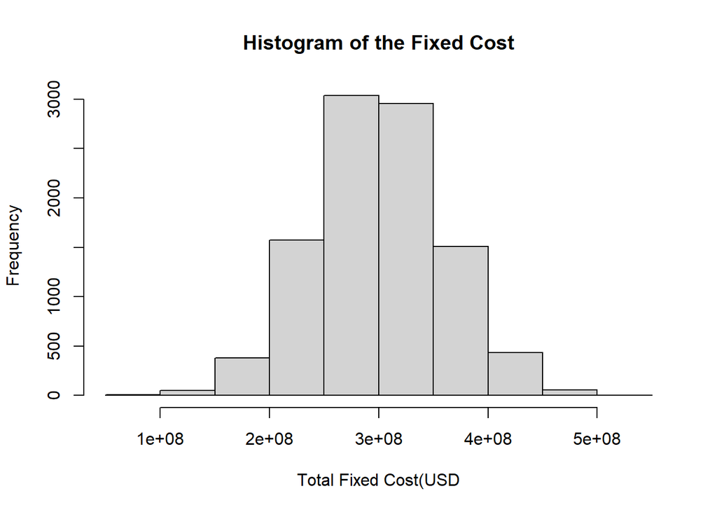

```r
# Setting seed for reproducibility
set.seed(616)
# Calculating fixed cost
fixed_cost <- rnorm(n=n, mean=300000000, sd=60000000)
hist(fixed_cost, main="Histogram of the Fixed Cost", xlab="Total Fixed Cost(USD")
```

#### 3. Variable Cost

The company expect that the variable cost to produce one boat will be a minimum of 77 thousand dollar and a maximum of 100 thousand dollar, with a most likely value of 90,000 dollar. The variable cost could therefore be modeled using the Triangular Distribution.

Below code will be used to model the variable cost using Triangular Distribution

[figure not shown]

```r
# Calculating variable cost
variable_cost <- function(number_production){
  set.seed(616)
  variablecost_rv <- rtriangle(n=10000, a=77000, b=100000, c=90000)
  var_cost <- number_production * variablecost_rv
  return(var_cost)}

# Calculating variable cost for each of the production scenario
variable_cost_all <- lapply(boat_production, variable_cost)

# Checking the histogram of one of the production scenario variable cost
hist(variable_cost_all[[1]], main="Total Variable Cost Histogram for 4000 Boats Production", xlab="Total Variable Cost(USD)")
```

#### 4. Total Cost

Total cost to manufacture a boat will be the total of the fixed cost and variable cost. Below code will be used to calculate the total cost to manufacture the boat for each of the production scenario.

[figure not shown]

```r
# Calculating total cost
total_cost <- lapply(variable_cost_all, function(x) x + fixed_cost)

# Checking the histogram of one of the production scenario total cost
hist(total_cost[[1]], main="Histogram of Total Cost for 4000 Boats Production")
```

After modeling each of the components from the profit equation, the profit distribution for each of the production scenario are as follow:

```r
# Calculating profit all for line and ribbon plot to depict mean profit with 80% and 95% confidence interval
profit_all <- Map("-", total_revenue, total_cost)
profit_all_2 <- format(profit_all, scientific = FALSE)
# Calculating profit all for overlapped density plot of mean profit
profit_all_3 <- Map("-", total_revenue_2, total_cost)
profit_all_4 <- format(profit_all_3, scientific = FALSE)
```

### Plotting Histogram and Calculating Mean & Standard Deviation

[figure not shown]

```r
# Histogram
hist(profit_all[[1]], main="Profit Distribution of 4000 Boats Production", xlab="Profit(USD)")
```

```r
# Mean
paste("Mean of profit(loss) for 4000 boats production is (USD):",mean(profit_all[[1]])%>%round(2))
```

[output not shown]

```r
# Standard Deviation
paste("Standard Deviation of profit(loss) for 4000 boats production is (USD):", sd(profit_all[[1]])%>%round(2))
```

[output not shown]

[figure not shown]

```r
# Histogram
hist(profit_all[[2]], main="Profit Distribution of 8000 Boats Production", xlab="Profit(USD)")
```

```r
# Mean
paste("Mean of profit(loss) for 8000 boats production is (USD):",mean(profit_all[[2]])%>%round(2))
```

[output not shown]

```r
# Standard Deviation
paste("Standard Deviation of profit(loss) for 8000 boats production is (USD):", sd(profit_all[[2]])%>%round(2))
```

[output not shown]

[figure not shown]

```r
# Histogram
hist(profit_all[[3]], main="Profit Distribution of 12000 Boats Production", xlab="Profit(USD)")
```

```r
# Mean
paste("Mean of profit(loss) for 12000 boats production is (USD):",mean(profit_all[[3]])%>%round(2))
```

[output not shown]

```r
# Standard Deviation
paste("Standard Deviation of profit(loss) for 12000 boats production is (USD):", sd(profit_all[[3]])%>%round(2))
```

[output not shown]

[figure not shown]

```r
# Histogram
hist(profit_all[[4]], main="Profit Distribution of 15000 Boats Production", xlab="Profit(USD)")
```

```r
# Mean
paste("Mean of profit(loss) for 15000 boats production is (USD):",mean(profit_all[[4]])%>%round(2))
```

[output not shown]

```r
# Standard Deviation
paste("Standard Deviation of profit(loss) for 15000 boats production is (USD):", sd(profit_all[[4]])%>%round(2))
```

[output not shown]

### Line and Ribbon Plot of Mean Profit

Plotting line and ribbon plot to depict mean profit with 80% and 95% confidence interval

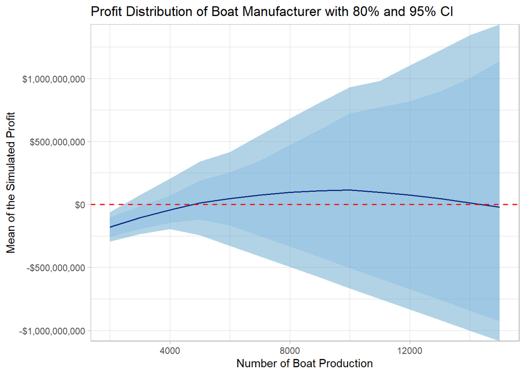

```r
# Calculating the mean
profit_mean <- sapply(profit_all, mean)

# Calculating quantile of 0.1 and 0.9 to deduce the 80% confidence interval
quantile_0.1 <- sapply(profit_all, function(x) quantile(x, 0.1))
quantile_0.9 <- sapply(profit_all, function(x) quantile(x, 0.9))

# Calculating quantile of 0.025 and 0.975 to deduce the 95% confidence interval
quantile_0.025 <- sapply(profit_all, function(x) quantile(x, 0.025))
quantile_0.975 <- sapply(profit_all, function(x) quantile(x, 0.975))

# Creating dataframe for plot
plot_df <- data.frame (production = boat_production, meanprofit = profit_mean,
                       q_0.1 = quantile_0.1, q_0.9 = quantile_0.9,
                       q_0.025 = quantile_0.025,q_0.975 = quantile_0.975)

# plotting line and ribbon plot showing the 80% and 95% confidence interval
ggplot(plot_df) +
  geom_ribbon(aes(x=production,ymin=q_0.1, ymax=q_0.9),alpha=0.3,fill='#8FC7ED') +
  geom_ribbon(aes(x=production,ymin=q_0.025,ymax=q_0.975),alpha=0.4,fill='#3F90C1') +
  geom_line(aes(x=production,y=meanprofit), color="#0C2C84", size=0.7) +
  scale_y_continuous(labels=scales::dollar_format(),expand=c(0,0)) +
  ggtitle("Profit Distribution of Boat Manufacturer with 80% and 95% CI") +
  xlab("Number of Boat Production") +
  ylab("Mean of the Simulated Profit") +
  theme_light() + geom_hline(yintercept = 0, linetype = "dashed", color = "red", size=0.7)
```

### Overlapped Density Plot of Mean Profit

Plotting the overlapped density plot for mean expected profit

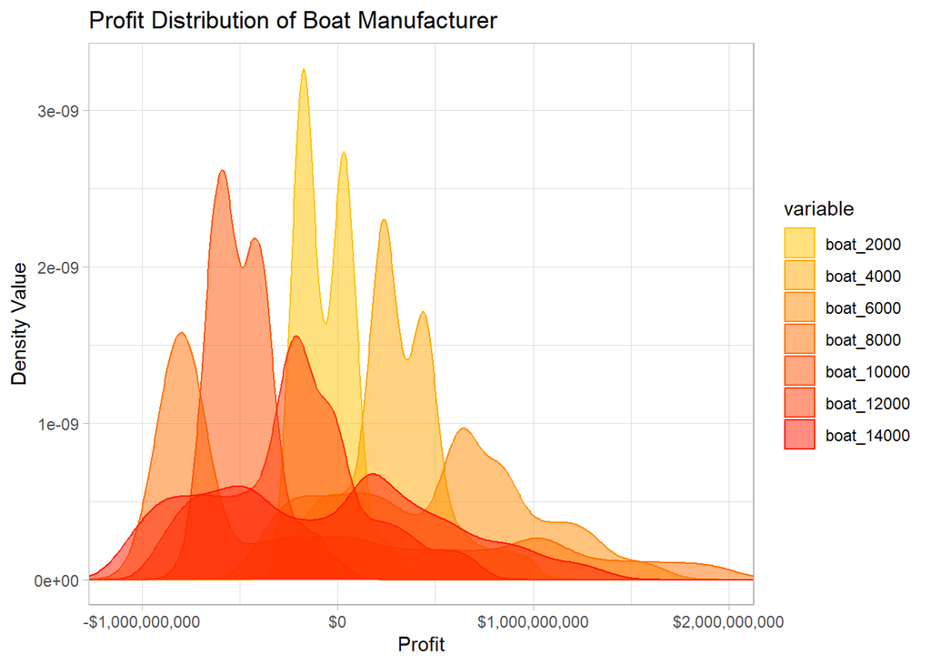

```r
# Bind the vectors together into a data frame
profit_df <- data.frame(matrix(unlist(profit_all_3), ncol = 7, byrow = FALSE))
colnames(profit_df) <- c("boat_2000", "boat_4000","boat_6000", "boat_8000",
                         "boat_10000", "boat_12000","boat_14000")

# Melt the data frame into long format
profit_df_long <- reshape2::melt(profit_df)

# Plotting overlapped density plot of production scenario 2000, 4000, 6000, 8000, 10000,12000, and 14000
ggplot(profit_df_long, aes(x = value, color=variable, fill=variable)) +
  geom_density(alpha = 0.5) +
  scale_color_manual(values = c("#FFC300", "#FFA700", "#FF8C00", "#FF6F00",
                                         "#FF5200", "#FF3700", "#FF1A00")) +
  scale_fill_manual(values = c("#FFC300", "#FFA700", "#FF8C00", "#FF6F00",
                                         "#FF5200", "#FF3700", "#FF1A00")) +
  scale_x_continuous(labels=scales::dollar_format(),expand=c(0,0)) +
  ggtitle("Profit Distribution of Boat Manufacturer") +
  xlab("Profit") +
  ylab("Density Value") +
  theme_light()
```

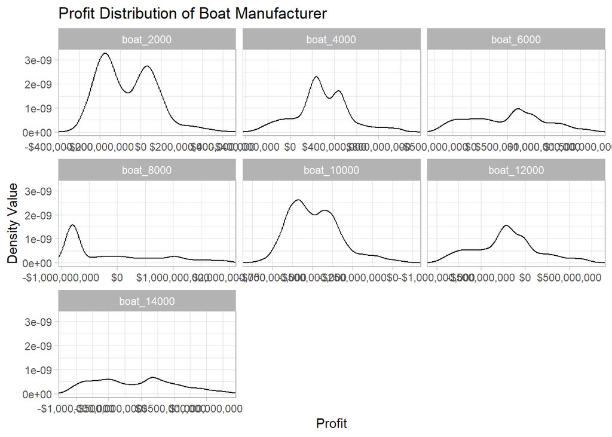

```r
# Plot density curves of production scenario 2000, 4000, 6000, 8000, 10000,12000, and 14000, separated by facet
ggplot(profit_df_long, aes(x = value)) +
  geom_density() +
  facet_wrap(~variable, scales = "free_x") +
  scale_x_continuous(labels=scales::dollar_format(),expand=c(0,0)) +
  ggtitle("Profit Distribution of Boat Manufacturer") +
  xlab("Profit") +
  ylab("Density Value") +
  theme_light()
```

## Number of Boat Production Optimization

Performing simulation optimization to determine the number of boats GWS should produce to maximize profit in three different approach:

**1. Optimizing number of boats to produce to maximize mean/expected profit**

```r
# Creating function to calculate the expected profit/mean profit
mean_profit<-function(number_of_boat){
  set.seed(616)
  n = 10000 # setting the simulation iterations
  sale_price <- 150000
  sale_price_left <- 70000
  p = runif(n) # Setting the randomly generated probability using Uniform Dist
  probs <- c(0.35, 0.75, 0.95, 1)
  ints <- c(2000, 5001, 10001, 14001, 15000)
  demand =  case_when(p<probs[1]~runif(n,ints[1],ints[2]),
               p<probs[2]~runif(n,ints[2],ints[3]),
               p<probs[3]~runif(n,ints[3],ints[4]),
               p<probs[4]~runif(n,ints[4],ints[5]))
  rv_demand <- demand
  m_rev <- rv_demand - number_of_boat
  revenue <- ifelse(m_rev>0, number_of_boat*sale_price, rv_demand*sale_price)
  m_rev_left <- rv_demand - number_of_boat
  left_revenue <- ifelse(m_rev>0, 0, rv_demand*sale_price_left)
  total_revenue <- revenue + left_revenue
  fixed_cost <- rnorm(n=n, mean=300000000, sd=60000000)
  variablecost_rv <- rtriangle(n=10000, a=77000, b=100000, c=90000)
  var_cost <- number_of_boat * variablecost_rv
  profit <- revenue + left_revenue - fixed_cost - var_cost
  return(mean(profit))
}
```

Finding the number of boat to produce to maximize mean profit using function created above:

```r
# Testing the mean_profit function
cat("The mean profit/loss of manufacturing 2000 boats is", mean_profit(number_of_boat = 2000) %>% format(big.mark = ","), "USD\n\n")
```

```
## The mean profit/loss of manufacturing 2000 boats is -178,597,964 USD
```

```r
# Optimizing the objective function using optimise function
opt_model <- optimise(f=mean_profit,interval=c(2000,15000),maximum=TRUE)

# Checking for the optimized function parameter
cat ("The number of boat that GWS should produce to maximize profit based on 10000 simulations is", opt_model$maximum %>% ceiling %>% format(big.mark = ","), "units\n\n")
```

```
## The number of boat that GWS should produce to maximize profit based on 10000 simulations is 9,915 units
```

```r
cat ("The expected profit from manufacturing above number of recommended boats is", opt_model$objective %>% ceiling %>% format(big.mark = ","), "USD")
```

```
## The expected profit from manufacturing above number of recommended boats is 114,817,265 USD
```

**2. Optimizing number of boats to produce to maximize the 10th percentile of GWS profit distribution**

```r
# Creating function to calculate the 10th percentile profit
quantile10_profit<-function(number_of_boat){
  set.seed(616)
  n = 10000
  sale_price <- 150000
  sale_price_left <- 70000
  p = runif(n)
  probs <- c(0.35, 0.75, 0.95, 1)
  ints <- c(2000, 5001, 10001, 14001, 15000)
  demand =  case_when(p<probs[1]~runif(n,ints[1],ints[2]),
               p<probs[2]~runif(n,ints[2],ints[3]),
               p<probs[3]~runif(n,ints[3],ints[4]),
               p<probs[4]~runif(n,ints[4],ints[5]))
  rv_demand <- demand
  m_rev <- rv_demand - number_of_boat
  revenue <- ifelse(m_rev>0, number_of_boat*sale_price, rv_demand*sale_price)
  m_rev_left <- rv_demand - number_of_boat
  left_revenue <- ifelse(m_rev>0, 0, rv_demand*sale_price_left)
  total_revenue <- revenue + left_revenue
  fixed_cost <- rnorm(n=n, mean=300000000, sd=60000000)
  variablecost_rv <- rtriangle(n=10000, a=77000, b=100000, c=90000)
  var_cost <- number_of_boat * variablecost_rv
  profit <- revenue + left_revenue - fixed_cost - var_cost
  return(quantile(profit, 0.1))}
```

Finding the number of boat to produce to maximize profit in the 10th percentile using function created above:

```r
# Testing the quantile10_profit function
cat("The mean profit/loss of manufacturing 2000 boats is", quantile10_profit(number_of_boat = 2000) %>% format(big.mark = ","), "USD\n\n")
```

[output not shown]

```r
# Optimizing the objective function using optimise function
opt_model_2 <- optimise(f=quantile10_profit,interval=c(2000,15000),maximum=TRUE)

# Checking for the optimized function parameter
cat ("The number of boat that GWS should produce to maximize profit on its 10th percentile profit distribution based on 10000 simulations is", opt_model_2$maximum %>% ceiling %>% format(big.mark = ","), "units\n\n")
```

```
## The number of boat that GWS should produce to maximize profit on its 10th percentile profit distribution based on 10000 simulations is 4,732 units
```

```r
cat ("The maximized profit on the 10th percentile of the profit distribution from manufacturing above number of recommended boats is", opt_model_2$objective %>% ceiling %>% format(big.mark = ","), "USD")
```

```
## The maximized profit on the 10th percentile of the profit distribution from manufacturing above number of recommended boats is -128,972,034 USD
```

**2. Optimizing number of boats to produce to maximize the probability of earning a profit of at least $50 million**

```r
# Creating function to calculate probability of getting the profit at least 50 million
mean_profit_50mil<-function(number_of_boat){
  set.seed(616)
  n = 10000
  sale_price <- 150000
  sale_price_left <- 70000
  p = runif(n)
  probs <- c(0.35, 0.75, 0.95, 1)
  ints <- c(2000, 5001, 10001, 14001, 15000)
  demand =  case_when(p<probs[1]~runif(n,ints[1],ints[2]),
               p<probs[2]~runif(n,ints[2],ints[3]),
               p<probs[3]~runif(n,ints[3],ints[4]),
               p<probs[4]~runif(n,ints[4],ints[5]))
  rv_demand <- demand
  m_rev <- rv_demand - number_of_boat
  revenue <- ifelse(m_rev>0, number_of_boat*sale_price, rv_demand*sale_price)
  m_rev_left <- rv_demand - number_of_boat
  left_revenue <- ifelse(m_rev>0, 0, rv_demand*sale_price_left)
  total_revenue <- revenue + left_revenue
  fixed_cost <- rnorm(n=n, mean=300000000, sd=60000000)
  variablecost_rv <- rtriangle(n=10000, a=77000, b=100000, c=90000)
  var_cost <- number_of_boat * variablecost_rv
  profit <- revenue + left_revenue - fixed_cost - var_cost
  return(mean(profit>=50000000))
}
```

Finding the number of boat to produce that return the highest probability of generating profit at least 50 million USD

```r
# Testing the quantile10_profit function
cat("The probability of getting profit of at least 50 million by manufacturing 2000 boats is", mean_profit_50mil(number_of_boat = 2000) %>% format(scientific = FALSE),"\n\n")
```

```
## The probability of getting profit of at least 50 million by manufacturing 2000 boats is 0.0002
```

```r
# Optimizing the objective function using optimise function
opt_model_3 <- optimise(f=mean_profit_50mil,interval=c(2000,15000),maximum=TRUE)

# Checking for the optimized function parameter
cat("The number of boat to produce to get the highest probability of getting profit of at least 50 million USD is",opt_model_3$maximum %>% ceiling(),".","That would yield the probability of", opt_model_3$objective %>% round(2) %>% format (scientific=FALSE), "from the entire simulation sample space.")
```

```
## The number of boat to produce to get the highest probability of getting profit of at least 50 million USD is 7413 . That would yield the probability of 0.67 from the entire simulation sample space.
```